# Practical Machine Learning Final Project - Prediction Assignment

Sacina Paudel

# PRACTICAL MACHINE LEARNING FINAL PROJECT REPORT

This report represents the final project for the Practical Machine Learning course on Coursera.

With the rise of affordable wearable technology such as Fitbit, Jawbone Up, and Nike FuelBand, it has become easier to collect vast amounts of data related to personal activities. The data from these devices can be used to improve one’s health or find trends in behaviors, though most people focus on measuring how much activity they perform rather than how well they perform it. This project aims to predict how well six participants performed barbell lifts, based on data from accelerometers located on their belt, forearm, arm, and dumbbell.

Further details on this dataset can be found at the following source: http://web.archive.org/web/20161224072740/http:/groupware.les.inf.puc-rio.br/har

Data Sources The training data for this project are available here:

https://d396qusza40orc.cloudfront.net/predmachlearn/pml-training.csv

The test data are available here:

https://d396qusza40orc.cloudfront.net/predmachlearn/pml-testing.csv

## Project Objective

The primary goal is to predict the manner of exercise using the “classe” variable in the training data, based on accelerometer readings. The analysis should include model building, cross-validation, error estimation, and prediction of test cases. The final deliverable should consist of an R Markdown file and a compiled HTML report, which must be under 2,000 words and contain fewer than five figures.

Reproducibility Since the R code itself will not be executed during the evaluation, ensure that the HTML report can be viewed by downloading the repository.

```r
# Load necessary libraries
library(randomForest)
library(caret)
library(dplyr)
```

### Data Loading and Preparation

```r
train_url <- "https://d396qusza40orc.cloudfront.net/predmachlearn/pml-training.csv"
test_url <- "https://d396qusza40orc.cloudfront.net/predmachlearn/pml-testing.csv"

# Download and read in the training and test datasets
train_set <- read.csv(train_url, na.strings = c("NA", ""))
test_set <- read.csv(test_url, na.strings = c("NA", ""))
```

Explore data

```r
#check the training data structure
str(train_set)
```

```
## 'data.frame':    19622 obs. of  160 variables:
##  $ X                       : int  1 2 3 4 5 6 7 8 9 10 ...
##  $ user_name               : chr  "carlitos" "carlitos" "carlitos" "carlitos" ...
##  $ raw_timestamp_part_1    : int  1323084231 1323084231 1323084231 1323084232 1323084232 1323084232 1323084232 1323084232 1323084232 1323084232 ...
##  $ raw_timestamp_part_2    : int  788290 808298 820366 120339 196328 304277 368296 440390 484323 484434 ...
##  $ cvtd_timestamp          : chr  "05/12/2011 11:23" "05/12/2011 11:23" "05/12/2011 11:23" "05/12/2011 11:23" ...
##  $ new_window              : chr  "no" "no" "no" "no" ...
##  $ num_window              : int  11 11 11 12 12 12 12 12 12 12 ...
##  $ roll_belt               : num  1.41 1.41 1.42 1.48 1.48 1.45 1.42 1.42 1.43 1.45 ...
##  $ pitch_belt              : num  8.07 8.07 8.07 8.05 8.07 8.06 8.09 8.13 8.16 8.17 ...
##  $ yaw_belt                : num  -94.4 -94.4 -94.4 -94.4 -94.4 -94.4 -94.4 -94.4 -94.4 -94.4 ...
##  $ total_accel_belt        : int  3 3 3 3 3 3 3 3 3 3 ...
##  $ kurtosis_roll_belt      : chr  NA NA NA NA ...
##  $ kurtosis_picth_belt     : chr  NA NA NA NA ...
##  $ kurtosis_yaw_belt       : chr  NA NA NA NA ...
```

[output cut: 86 more lines]

```r
# Check for missing values
sum(is.na(train_set))
```

```
## [1] 1921600
```

### Cleaning the Data

We need to clean the data by removing irrelevant columns, handling missing values, and ensuring the target variable (classe) is a factor.

```r
# Remove irrelevant columns (e.g., identifiers, timestamps)
train_set_clean <- train_set %>%
  select(-X, -user_name, -raw_timestamp_part_1, -raw_timestamp_part_2, -cvtd_timestamp, -new_window, -num_window)

# Remove columns with near-zero variance
nzv <- nearZeroVar(train_set_clean, saveMetrics = TRUE)
train_set_clean <- train_set_clean[, !nzv$nzv]

# Remove columns with too many missing values
train_set_clean <- train_set_clean[, colSums(is.na(train_set_clean)) == 0]

# Ensure 'classe' is a factor variable
train_set_clean$classe <- as.factor(train_set_clean$classe)

# Final structure of cleaned training set
str(train_set_clean)
```

```
## 'data.frame':    19622 obs. of  53 variables:
##  $ roll_belt           : num  1.41 1.41 1.42 1.48 1.48 1.45 1.42 1.42 1.43 1.45 ...
##  $ pitch_belt          : num  8.07 8.07 8.07 8.05 8.07 8.06 8.09 8.13 8.16 8.17 ...
##  $ yaw_belt            : num  -94.4 -94.4 -94.4 -94.4 -94.4 -94.4 -94.4 -94.4 -94.4 -94.4 ...
##  $ total_accel_belt    : int  3 3 3 3 3 3 3 3 3 3 ...
##  $ gyros_belt_x        : num  0 0.02 0 0.02 0.02 0.02 0.02 0.02 0.02 0.03 ...
##  $ gyros_belt_y        : num  0 0 0 0 0.02 0 0 0 0 0 ...
##  $ gyros_belt_z        : num  -0.02 -0.02 -0.02 -0.03 -0.02 -0.02 -0.02 -0.02 -0.02 0 ...
##  $ accel_belt_x        : int  -21 -22 -20 -22 -21 -21 -22 -22 -20 -21 ...
##  $ accel_belt_y        : int  4 4 5 3 2 4 3 4 2 4 ...
##  $ accel_belt_z        : int  22 22 23 21 24 21 21 21 24 22 ...
##  $ magnet_belt_x       : int  -3 -7 -2 -6 -6 0 -4 -2 1 -3 ...
##  $ magnet_belt_y       : int  599 608 600 604 600 603 599 603 602 609 ...
##  $ magnet_belt_z       : int  -313 -311 -305 -310 -302 -312 -311 -313 -312 -308 ...
##  $ roll_arm            : num  -128 -128 -128 -128 -128 -128 -128 -128 -128 -128 ...
```

[output cut: 39 more lines]

5. Partition the Data split the data into a training set and a validation set to evaluate the model’s performance.

```r
# Partition the data: 70% training, 30% validation
set.seed(123)  # For reproducibility
trainIndex <- createDataPartition(train_set_clean$classe, p = 0.7, list = FALSE)
train_data <- train_set_clean[trainIndex, ]
validation_data <- train_set_clean[-trainIndex, ]
```

6. Train the Random Forest Model Now, train a Random Forest model using the randomForest package.

```r
# Train Random Forest model
set.seed(123)
rf_model <- randomForest(classe ~ ., data = train_data, importance = TRUE, ntree = 200)

# Display model summary
print(rf_model)
```

```
##
## Call:
##  randomForest(formula = classe ~ ., data = train_data, importance = TRUE,      ntree = 200)
##                Type of random forest: classification
##                      Number of trees: 200
## No. of variables tried at each split: 7
##
##         OOB estimate of  error rate: 0.54%
## Confusion matrix:
##      A    B    C    D    E  class.error
## A 3903    2    1    0    0 0.0007680492
## B   11 2641    6    0    0 0.0063957863
## C    0   14 2377    5    0 0.0079298831
## D    0    0   28 2223    1 0.0128774423
## E    0    0    2    4 2519 0.0023762376
```

7. Evaluate the Model You can now evaluate the Random Forest model on the validation dataset.

```r
# Make predictions on the validation dataset
predictions <- predict(rf_model, validation_data)

# Generate the confusion matrix to assess performance
confusionMatrix(predictions, validation_data$classe)
```

```
## Confusion Matrix and Statistics
##
##           Reference
## Prediction    A    B    C    D    E
##          A 1674    4    0    0    0
##          B    0 1131    3    0    0
##          C    0    4 1023    9    4
##          D    0    0    0  955    4
##          E    0    0    0    0 1074
##
## Overall Statistics
##
##                Accuracy : 0.9952
##                  95% CI : (0.9931, 0.9968)
##     No Information Rate : 0.2845
##     P-Value [Acc > NIR] : < 2.2e-16
##
##                   Kappa : 0.994
##
##  Mcnemar's Test P-Value : NA
##
## Statistics by Class:
##
##                      Class: A Class: B Class: C Class: D Class: E
## Sensitivity            1.0000   0.9930   0.9971   0.9907   0.9926
## Specificity            0.9991   0.9994   0.9965   0.9992   1.0000
## Pos Pred Value         0.9976   0.9974   0.9837   0.9958   1.0000
## Neg Pred Value         1.0000   0.9983   0.9994   0.9982   0.9983
## Prevalence             0.2845   0.1935   0.1743   0.1638   0.1839
## Detection Rate         0.2845   0.1922   0.1738   0.1623   0.1825
## Detection Prevalence   0.2851   0.1927   0.1767   0.1630   0.1825
## Balanced Accuracy      0.9995   0.9962   0.9968   0.9949   0.9963
```

8. Feature Importance The Random Forest model provides a measure of feature importance. Let’s plot the most important features.

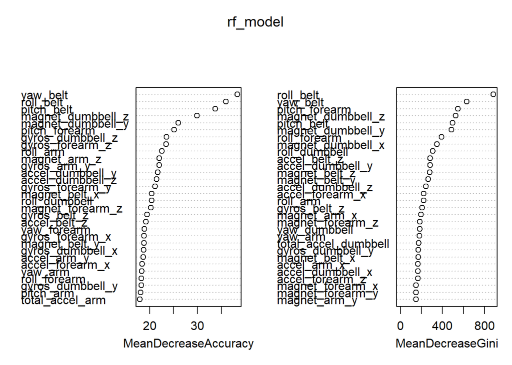

```r
# Plot feature importance
varImpPlot(rf_model)
```

9. Test Set Predictions Once the model is validated, apply it to the test set to make predictions.

```r
# Clean test set similar to train set
test_set_clean <- test_set %>%
  select(-X, -user_name, -raw_timestamp_part_1, -raw_timestamp_part_2, -cvtd_timestamp, -new_window, -num_window) %>%
  select_if(function(col) !any(is.na(col)))

# Make predictions on the test set
test_predictions <- predict(rf_model, test_set_clean)
```

10. Save Predictions for Submission You can generate files with predictions for submission.

```r
# Function to generate output files
pml_write_files = function(x){
  n = length(x)
  for(i in 1:n){
    filename = paste0("./problem_id_",i,".txt")
    write.table(x[i], file=filename, quote=FALSE, row.names=FALSE, col.names=FALSE)
  }
}

# Create files for test predictions
pml_write_files(test_predictions)
```